# Visualisation de données avec R

Bioinformatique I (BIF-7900)

Antoine Bodein

15 octobre 2026

# Introduction

## Objectifs

Deux examens du cours, 79 étudiants (`grades.tsv`, module 6). Les deux moyennes :

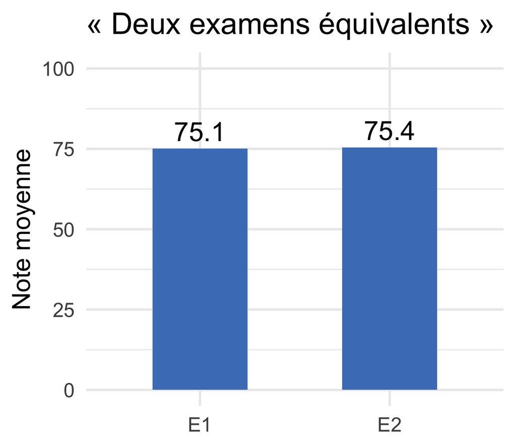

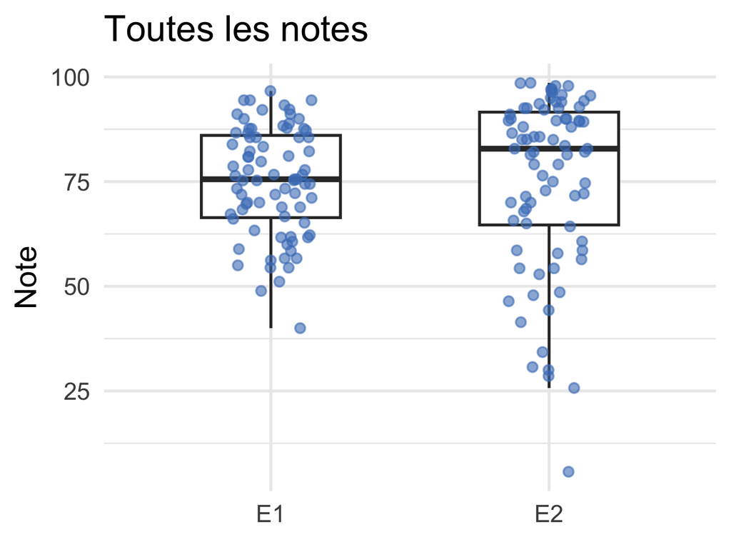

**Même moyenne, deux examens différents** : E2 a une médiane plus haute, mais une dizaine d’échecs. Le barplot n’a rien caché par erreur : il **résume**, et le résumé était le mauvais choix.

## Objectifs

1. Faire les graphiques usuels avec **R de base** (`plot()`, `hist()`, `boxplot()`)
2. Comprendre la **grammaire** de `ggplot2` : données, *aesthetics*, *geoms*, couches
3. Ajuster un graphique : statistiques, positions, **échelles**, facettes, thèmes
4. **Préparer** les données pour `ggplot2` : format long, ordre des catégories, groupes
5. Construire les graphiques de la **bioinformatique** (volcano plot, heatmap) et **choisir** le bon graphique

## Plan

1. Introduction
2. Les graphiques de R de base
3. La grammaire de `ggplot2` → **TP1**
4. Ajuster un graphique
5. Préparer les données → **TP2**
6. Graphiques de la bioinformatique et bonnes pratiques → **TP3**
7. Activité : auditer un script `ggplot2` généré par IA

## Où en est-on ?

[figure not shown]

Importer

➜

[figure not shown]

Ranger

➜

[figure not shown]

Transformer

➜

[figure not shown]

Visualiser

- **Module 6** : importer (`readr`), ranger (`tidyr`), transformer (`dplyr`)
- **Aujourd’hui : visualiser.** On réutilise tout : un graphique `ggplot2` part d’un tableau **rangé**, souvent après un `pivot_longer()` ou un `summarise()`
- **Module suivant** : modéliser (statistiques), pour dire si ce qu’on voit sur le graphique dépasse le hasard

## Pourquoi des graphiques en lignes de code ?

- **Reproductible** : le script refait le graphique à l’identique, sur les nouvelles données de la semaine prochaine
- **Modifiable** : changer une couleur, un seuil, un ordre, en une ligne
- **Partageable** : le code accompagne la figure de l’article
- Des milliers de packages spécialisés (génomique, réseaux, cartes)

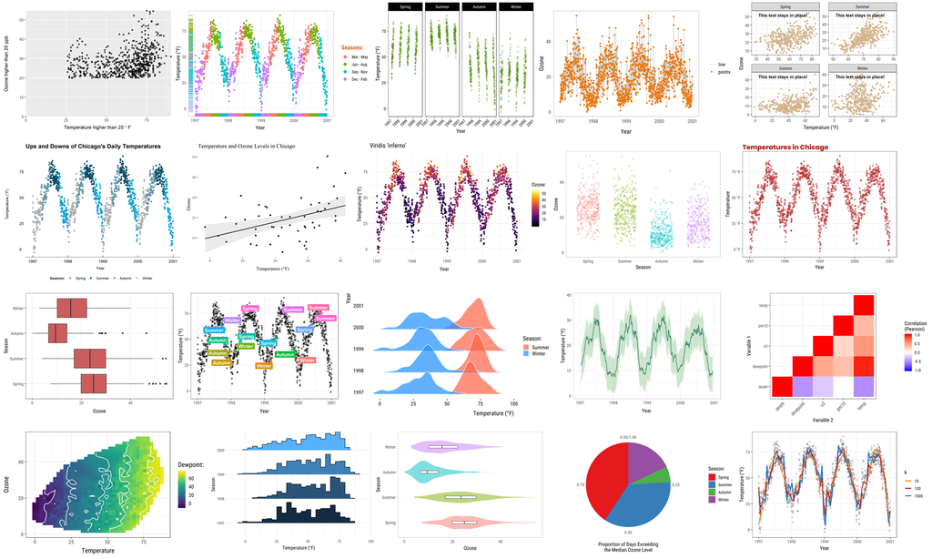

Quelques graphiques `ggplot2` (C. Scherer, *A ggplot2 tutorial for beautiful plotting in R*)

Un graphique est souvent **la première vérification** d’une analyse : il montre les valeurs aberrantes, les `NA`, les groupes mal codés, les distributions bizarres, que les moyennes et les tests cachent. Un assistant d’IA écrit le code d’un graphique en une seconde ; **lire** le graphique, et voir ce qu’il ne montre pas, reste votre travail.

# Les graphiques de R de base

## La fonction `plot()`

`plot()` choisit le graphique selon le **type** de ce qu’on lui donne :

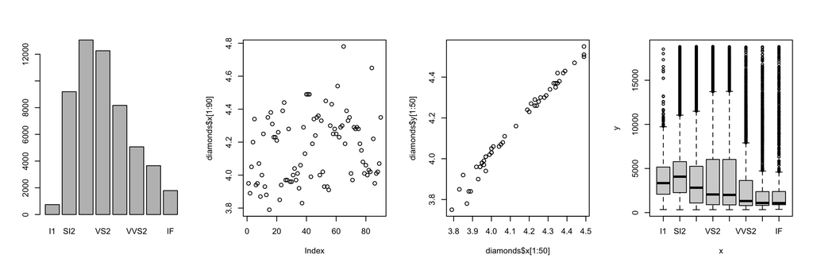

```r
par(mfrow = c(1, 4))                      # 4 graphiques côte à côte
plot(diamonds$clarity)                    # un facteur : barplot des effectifs
plot(diamonds$x[1:90])                    # un vecteur numérique : valeur selon la position
plot(diamonds$x[1:50], diamonds$y[1:50])  # deux numériques : nuage de points
plot(diamonds$clarity, diamonds$price)    # facteur + numérique : boxplots
```

`diamonds` (inclus dans `ggplot2`) : prix, poids (`carat`), taille, couleur et pureté (`clarity`) de 53 940 diamants.

## Les arguments de `plot()`

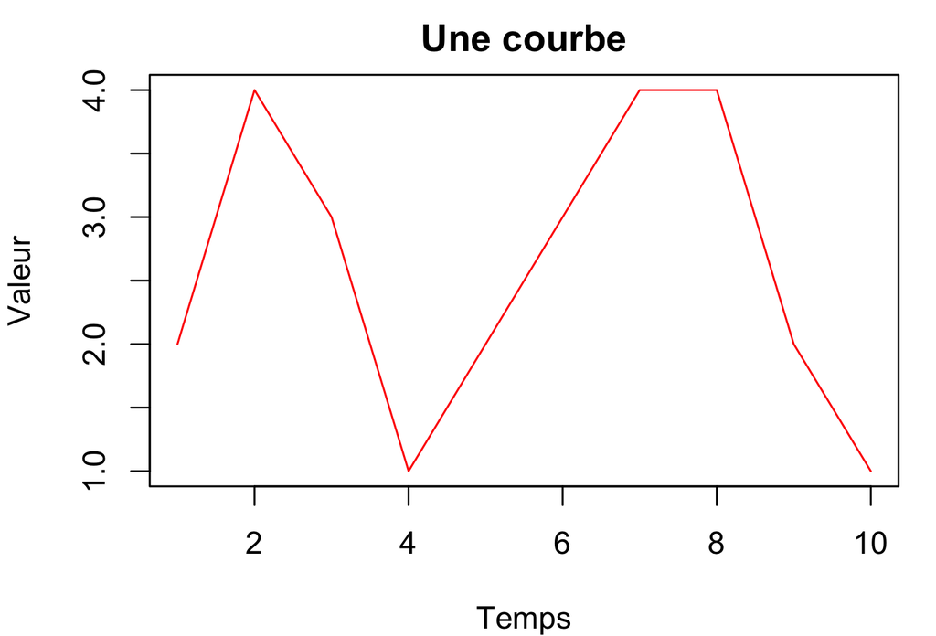

```r
x <- 1:10
y <- c(2, 4, 3, 1, 2, 3, 4, 4, 2, 1)
plot(x = x, y = y, type = "l", col = "red",
     main = "Une courbe", xlab = "Temps",
     ylab = "Valeur")
```

| Argument | Rôle |
| --- | --- |
| `x`, `y` | les valeurs ; ou la formule `plot(y ~ x)` |
| `type` | `"p"` points, `"l"` lignes, `"b"` les deux |
| `main`, `xlab`, `ylab` | titre, titres des axes |
| `xlim`, `ylim` | limites des axes : `xlim = c(1, 3)` |
| `col` | couleur |
| `pch`, `lty` | forme des points, type de ligne |

Toutes les options : `help(plot)`, `help(par)`

## Ajouter des couches : `lines()`, `points()`, `legend()`

```r
z <- c(4, 3, 5, 5, 3, 4, 3, 5, 4, 3)
plot(x, y, type = "l", col = "red",
     ylim = c(1, 5), main = "2 variables")
lines(x, z, col = "blue", lty = 2)
legend("bottomleft", legend = c("y", "z"),
       col = c("red", "blue"), lty = c(1, 2))
```

- `plot()` **ouvre** un graphique
- `lines()`, `points()`, `abline()`, `text()`, `legend()` **ajoutent** sur le graphique ouvert
- Les limites sont fixées par le premier `plot()` : d’où `ylim`

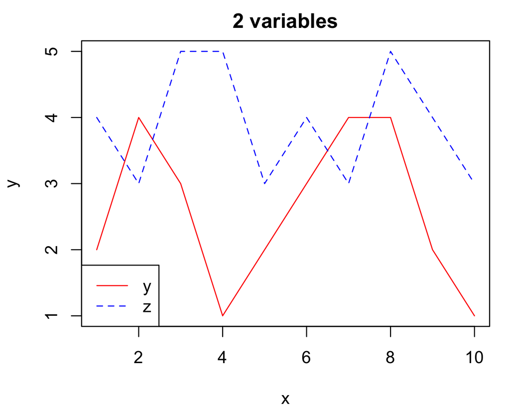

## Histogramme, barplot, boxplot, heatmap

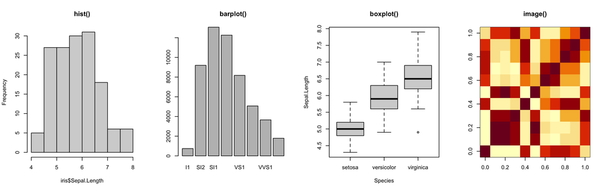

```r
par(mfrow = c(1, 4))
hist(iris$Sepal.Length, main = "hist()")              # distribution d'un numérique
barplot(table(diamonds$clarity), main = "barplot()")  # hauteurs déjà calculées (effectifs)
boxplot(Sepal.Length ~ Species, data = iris, main = "boxplot()")
image(cor(mtcars), main = "image()")                  # une matrice en couleurs
```

## Sauvegarder un graphique

```r
# 1. ouvrir un fichier graphique : png(), jpeg(), tiff(), pdf(), svg()
png("figures/mon_graphique.png", width = 1600, height = 1200, res = 200)

# 2. faire le graphique (il ne s'affiche pas : il s'écrit dans le fichier)
boxplot(Sepal.Length ~ Species, data = iris)

# 3. fermer le fichier
dev.off()
```

- Oublier `dev.off()` : le fichier reste **vide** ou incomplet, et les graphiques suivants s’y écrivent aussi
- `pdf()` peut contenir **plusieurs pages** : un graphique par page jusqu’au `dev.off()`
- Dans RStudio : onglet *Plots* > *Export*, pratique mais **pas reproductible**

## Piège : la légende écrite à la main

```r
plot(iris$Petal.Length, iris$Petal.Width,
     col = iris$Species, pch = 19)
legend("topleft",
       legend = c("virginica", "versicolor",
                  "setosa"),
       col = 1:3, pch = 19)
```

- `col = iris$Species` : R utilise le **numéro** du niveau du facteur : setosa = 1 (noir), versicolor = 2 (rouge), virginica = 3 (vert)
- La légende, elle, est **un texte libre** : R ne vérifie pas qu’elle correspond aux couleurs
- **Aucun message**, et un graphique faux : les petites fleurs noires sont des *setosa*

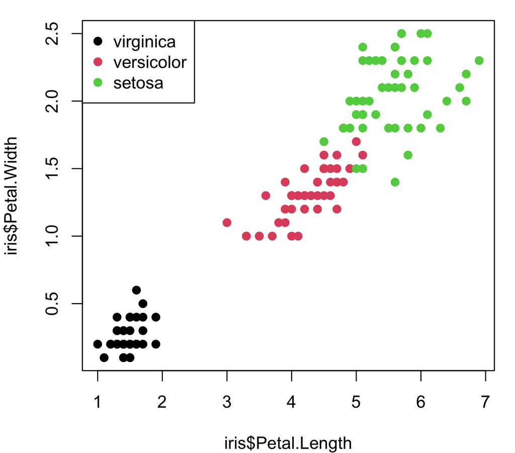

Correction : `legend = levels(iris$Species)`. Avec `ggplot2`, la légende est **construite à partir des données** : ce piège disparaît.

## À vous : quel graphique ?

Sans exécuter, quel graphique produit chaque appel ?

```r
plot(iris$Species)                           # 1
plot(iris$Sepal.Length)                      # 2
plot(iris$Sepal.Length, iris$Sepal.Width)    # 3
plot(iris$Species, iris$Sepal.Length)        # 4
hist(iris$Species)                           # 5
```

1. Un **barplot** des effectifs (50 par espèce)
2. Les 150 longueurs **selon leur position** dans le tableau (axe x : de 1 à 150)
3. Un **nuage de points** : largeur selon longueur
4. Trois **boxplots**, un par espèce
5. Une **erreur** : `'x' must be numeric`. Un histogramme découpe un axe **numérique** en intervalles

# La grammaire de `ggplot2`

## Une grammaire des graphiques

> *« In brief, the grammar tells us that a graphic maps the **data** to the **aesthetic attributes** (colour, shape, size) of **geometric objects** (points, lines, bars). »*

> H. Wickham, *ggplot2: Elegant Graphics for Data Analysis*

**Avantages**

- Une **grammaire** cohérente (L. Wilkinson, 2005) : les mêmes règles pour tous les graphiques
- Des couches qu’on **ajoute** une à une
- Légendes et axes construits **à partir des données**
- Fait partie du *tidyverse* : attend un tableau **rangé**

**Limites**

- Graphiques en 3D
- Réseaux et graphes (voir `igraph`, module réseaux)
- Graphiques interactifs (voir `plotly`)
- Heatmaps annotées : plus simple avec `pheatmap` ou `ComplexHeatmap`

## Un graphique en trois ingrédients

ggplot(data = fruit, mapping = aes(x = FRUIT, y = QUANTITE)) + geom_col()

① les données : un tableau

② le mapping : quelle colonne va sur quelle propriété visuelle

③ le geom : avec quelle forme dessiner

- `ggplot()` crée le graphique **vide** ; chaque `+` **ajoute une couche**
- Le `+` **termine la ligne** : une ligne qui commence par `+` est une nouvelle commande, et R ne trace que la première partie
- Les autres couches sont **facultatives** : `stat`, `position`, `scale_*()`, `coord_*()`, `facet_*()`, `theme()`, `labs()`

`ggplot2` est le package ; `ggplot()` est la fonction. Ne pas confondre le `+` de `ggplot2` (ajouter une couche) et le pipe `|>` (passer un résultat à la fonction suivante).

## Du tableau au graphique

`ggplot(fruit, aes(x = FRUIT, y = QUANTITE, fill = COULEUR)) + geom_col()`

fruit.tsv (extrait)

FRUITCOULEURQUANTITE

FraiseRouge10

BananeJaune5

AbricotOrange4

KiwiVert2

CitronJaune9

CitronVert8

Chaque **ligne** du tableau deviendra **une barre** ; chaque **colonne** peut être reliée à une propriété visuelle.

## Du tableau au graphique

`ggplot(fruit, aes(x = FRUIT, y = QUANTITE, fill = COULEUR)) + geom_col()`

le mapping

x = FRUITy = QUANTITEfill = COULEUR

FraiseRouge10

BananeJaune5

AbricotOrange4

KiwiVert2

CitronJaune9

CitronVert8

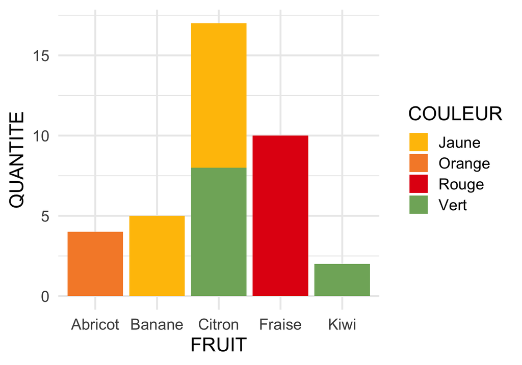

`aes()` répond à **quoi** : quelle colonne sur quel axe, quelle couleur. Le geom répond à **comment** : des barres, des points, des lignes.

## Les *aesthetics*

Les propriétés visuelles qu’on peut relier à une colonne, dans `aes()` :

| *Aesthetic* | Propriété | Geoms |
| --- | --- | --- |
| `x`, `y` | position | tous |
| `color` (ou `colour`) | couleur du contour, des points, des lignes | tous |
| `fill` | couleur de **remplissage** | barres, boxplots, surfaces |
| `size`, `linewidth` | taille des points, épaisseur des lignes | points, lignes |
| `shape` | forme des points | points |
| `alpha` | transparence (de 0 à 1) | tous |
| `group` | quelles lignes forment **un même objet** (une courbe) | lignes, boxplots |
| `label` | le texte affiché | `geom_text()`, `geom_label()` |

Une barre a un contour (`color`) **et** un intérieur (`fill`) : `aes(color = COULEUR)` sur `geom_col()` ne colore que le bord.

## *Mapping* ou *setting* ?

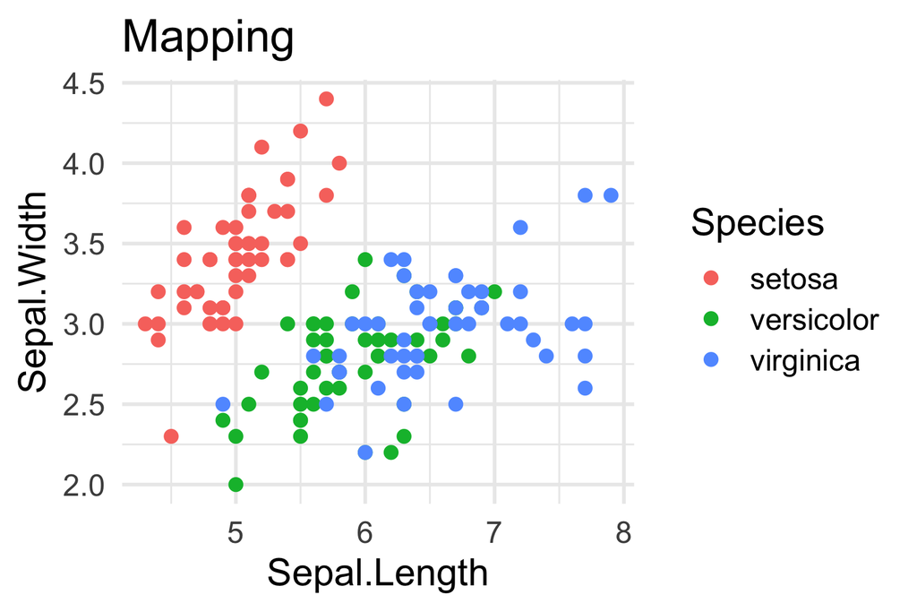

```r
ggplot(iris, aes(Sepal.Length, Sepal.Width)) +
  geom_point(aes(color = Species))
```

**Mapping**, dans `aes()` : la couleur **dépend d’une colonne**. `ggplot2` choisit les couleurs et crée une **légende**.

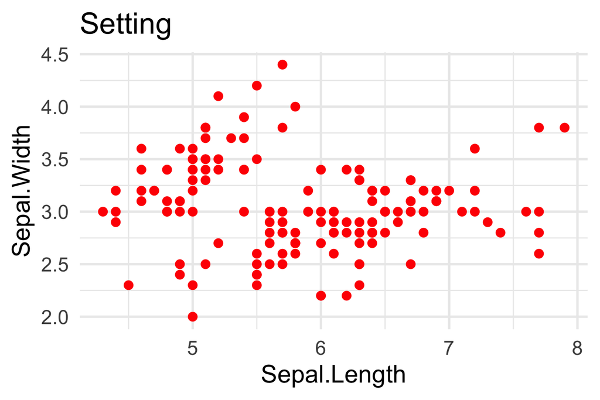

```r
ggplot(iris, aes(Sepal.Length, Sepal.Width)) +
  geom_point(color = "red")
```

**Setting**, hors de `aes()` : une **valeur fixe** pour tous les points. Pas de légende.

## Piège : une constante dans `aes()`

```r
ggplot(iris, aes(Sepal.Length, Sepal.Width)) +
  geom_point(aes(color = "blue"))
```

Que va-t-on obtenir ?

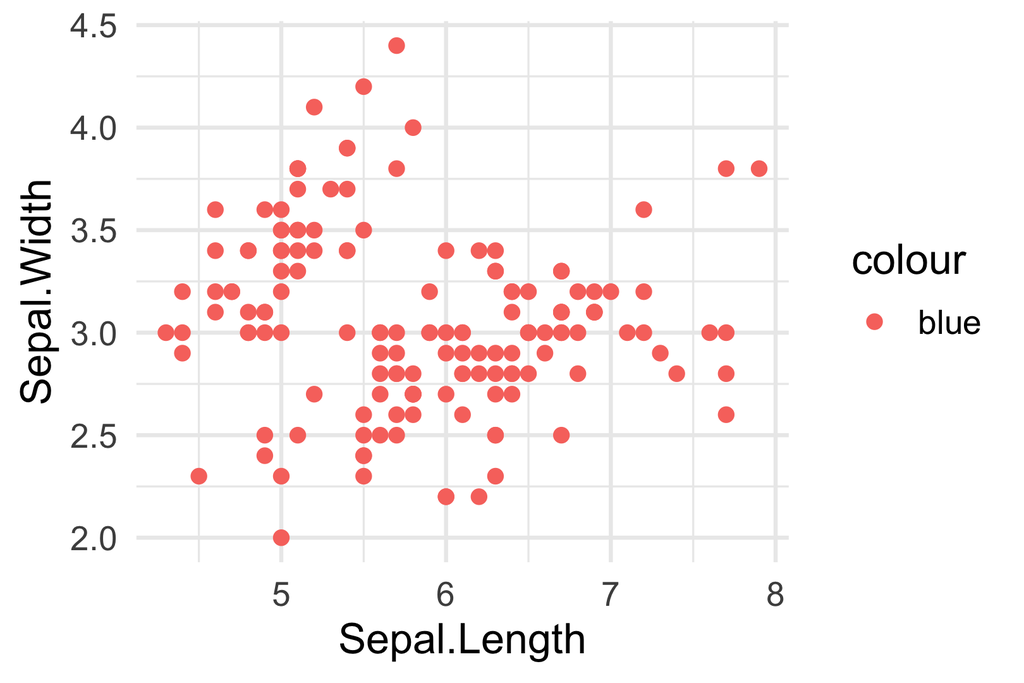

- Dans `aes()`, `"blue"` n’est pas une couleur : c’est **une donnée**, une colonne qui vaudrait `"blue"` pour chaque ligne
- `ggplot2` lui attribue la **première couleur de sa palette** (un rouge saumon), et une légende « blue »
- Aucun message. Règle : une **colonne** dans `aes()`, une **valeur fixe** hors de `aes()`

## Superposer des couches

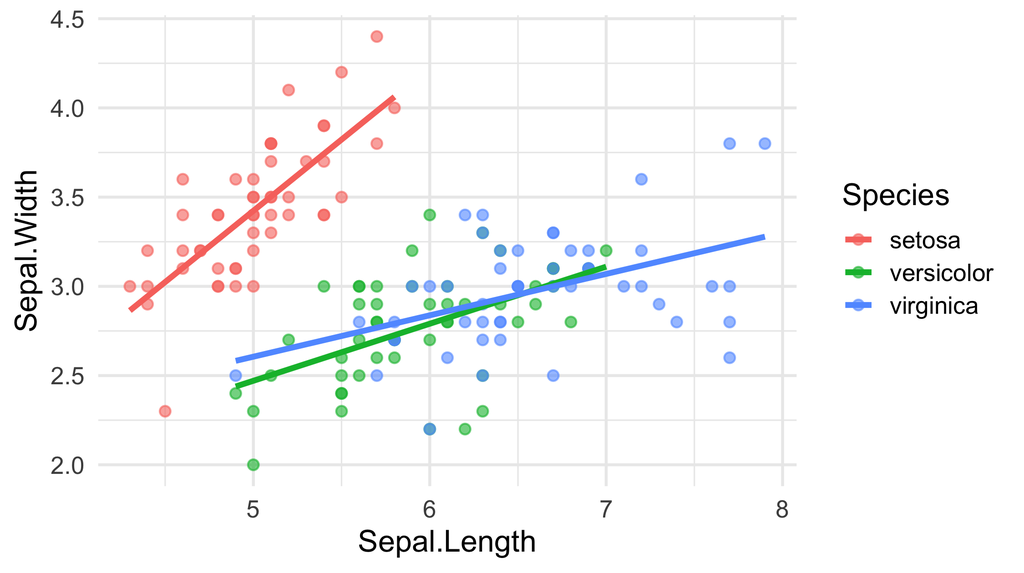

```r
ggplot(iris, aes(x = Sepal.Length, y = Sepal.Width, color = Species)) +
  geom_point(alpha = 0.6) +                   # couche 1 : les points
  geom_smooth(method = "lm", se = FALSE)      # couche 2 : une droite de régression par espèce
```

Les couches se dessinent **dans l’ordre** : la dernière passe par-dessus les autres.

## Où placer `aes()` ?

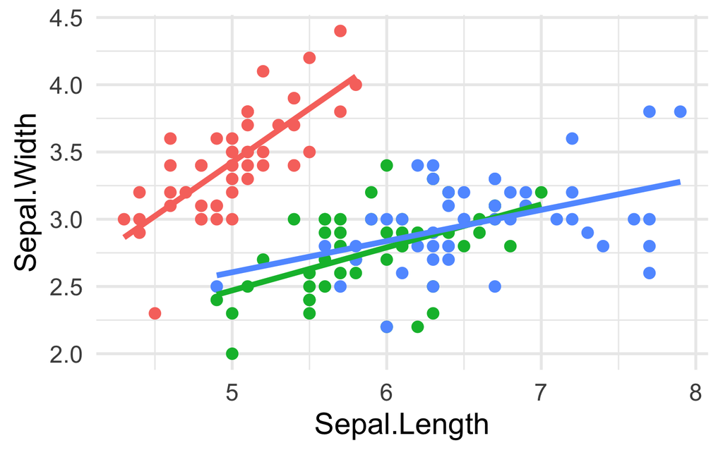

```r
ggplot(iris, aes(Sepal.Length, Sepal.Width,
                 color = Species)) +
  geom_point() +
  geom_smooth(method = "lm", se = FALSE)
```

Dans `ggplot()` : l’*aesthetic* vaut pour **toutes les couches** : trois droites.

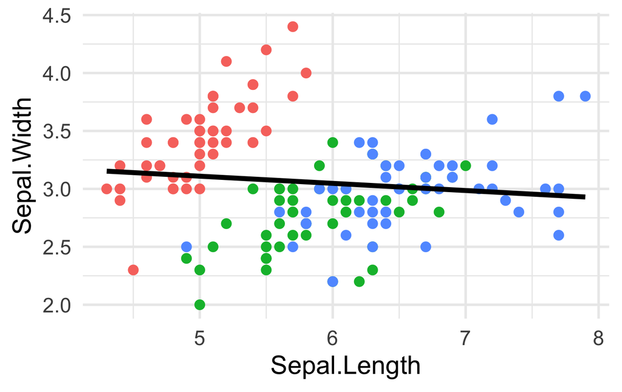

```r
ggplot(iris, aes(Sepal.Length, Sepal.Width)) +
  geom_point(aes(color = Species)) +
  geom_smooth(method = "lm", se = FALSE)
```

Dans un geom : seulement **cette couche** : une seule droite, pour toutes les fleurs.

Les deux graphiques sont justes ; ils ne répondent pas à la même question. La pente globale est **négative**, les pentes par espèce **positives** (un paradoxe de Simpson, module 9).

## Les *geoms*

Le choix du geom dépend du **nombre** et du **type** des variables à représenter :

| Variables | Geoms |
| --- | --- |
| 1 numérique | `geom_histogram()`, `geom_density()`, `geom_boxplot()` |
| 1 catégorielle | `geom_bar()` (compte les lignes) |
| 1 catégorielle + 1 numérique | `geom_boxplot()`, `geom_violin()`, `geom_jitter()`, `geom_col()` |
| 2 numériques | `geom_point()`, `geom_smooth()`, `geom_line()` (si x est ordonné : temps) |
| 2 catégorielles | `geom_count()`, `geom_tile()` |
| Repères | `geom_hline()`, `geom_vline()`, `geom_abline()`, `geom_text()` |

Tous les geoms et leurs *aesthetics* : l’aide-mémoire *Data visualization with ggplot2* (Posit).

## L’aide-mémoire

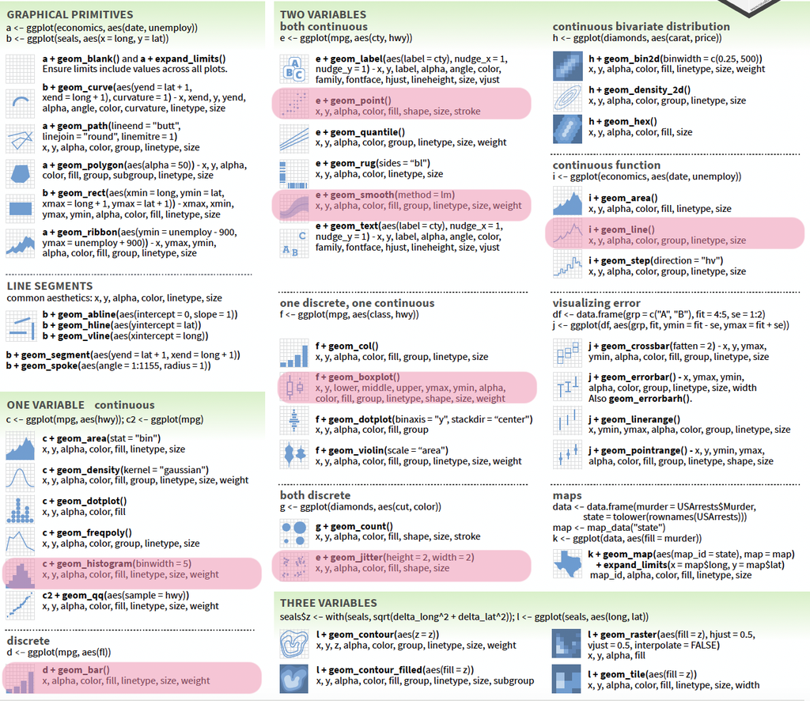

https://rstudio.github.io/cheatsheets/data-visualization.pdf

## À vous : prédire

Sans exécuter : un graphique (lequel ?) ou une erreur ?

```r
ggplot(iris, aes(Species, Sepal.Length)) + geom_point()                   # 1
ggplot(iris, aes(Sepal.Length)) + geom_point()                            # 2
ggplot(iris, aes(Sepal.Length, Sepal.Width)) + geom_point(color = Species) # 3
ggplot(iris, aes(Sepal.Length, Sepal.Width))                              # 4
ggplot(iris, aes(Sepal.Length, Sepal.Width))
  + geom_point()                                                          # 5
```

1. Trois **colonnes de points** superposés, une par espèce (d’où `geom_jitter()`)
2. Erreur : `geom_point() requires the following missing aesthetics: y`
3. Erreur : `object 'Species' not found`. Hors de `aes()`, R cherche une **variable** `Species`, pas une colonne
4. Un graphique **vide**, avec les axes : il n’y a aucune couche de geom
5. Un graphique vide, **puis** une erreur sur la ligne `+ geom_point()` : le `+` doit **terminer** la ligne

# TP1

# Ajuster un graphique

## `geom_bar()` compte les lignes

`ggplot(fruit, aes(x = COULEUR)) + geom_bar()`

fruit (extrait), trié par couleur

FRUITCOULEURQUANTITE

BananeJaune5

CitronJaune9

AbricotOrange4

FraiseRouge10

KiwiVert2

CitronVert8

On ne donne que `x` : la hauteur de chaque barre est **calculée** par `geom_bar()`.

## `geom_bar()` compte les lignes

`ggplot(fruit, aes(x = COULEUR)) + geom_bar()`

6 lignes

FRUITCOULEURQUANTITE

BananeJaune5

CitronJaune9

AbricotOrange4

FraiseRouge10

KiwiVert2

CitronVert8

➜

stat = “count”

COULEURn

Jaune2

Orange1

Rouge1

Vert2

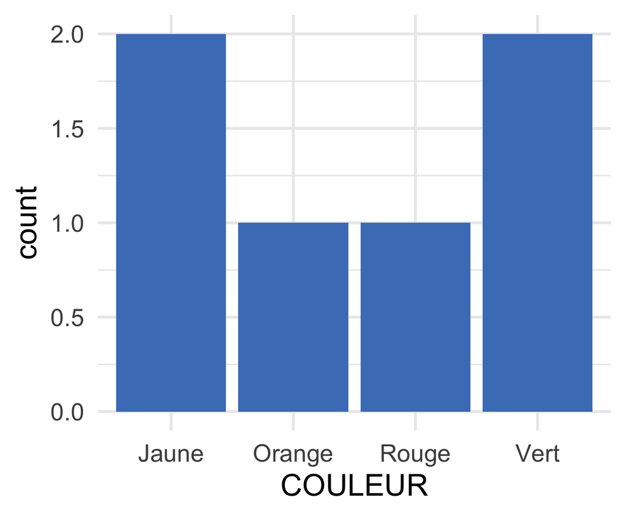

Chaque geom a une **statistique** par défaut : `geom_bar()` utilise `stat = "count"`, `geom_histogram()` `stat = "bin"`, `geom_boxplot()` `stat = "boxplot"`, `geom_point()` `stat = "identity"` (les valeurs telles quelles).

## `geom_col()` : la hauteur est dans les données

```r
ggplot(fruit, aes(x = FRUIT, y = QUANTITE)) +
  geom_col()

# équivalent (forme des anciens scripts) :
ggplot(fruit, aes(x = FRUIT, y = QUANTITE)) +
  geom_bar(stat = "identity")
```

- `geom_bar()` : **une** variable, il compte
- `geom_col()` : `x` **et** `y`, il trace `y` tel quel
- `geom_bar(aes(x, y))` sans `stat = "identity"` : erreur `must only have an x or y aesthetic`

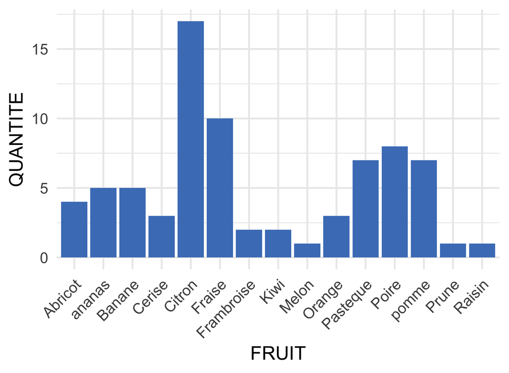

## Piège : plusieurs lignes pour une même barre

`ggplot(fruit, aes(x = FRUIT, y = QUANTITE)) + geom_col()`

fruit (extrait)

FRUITCOULEURQUANTITE

FraiseRouge10

BananeJaune5

AbricotOrange4

KiwiVert2

CitronJaune9

CitronVert8

Quelle sera la hauteur de la barre « Citron » ?

## Piège : plusieurs lignes pour une même barre

`ggplot(fruit, aes(x = FRUIT, y = QUANTITE)) + geom_col()`

2 lignes Citron

FRUITCOULEURQUANTITE

FraiseRouge10

BananeJaune5

AbricotOrange4

KiwiVert2

CitronJaune9

CitronVert8

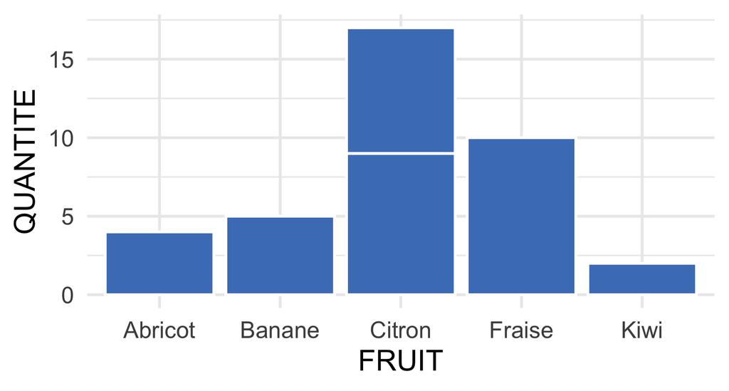

- `geom_col()` **empile** les lignes de même `x` : la barre vaut 9 + 8 = **17**, la **somme**. Aucun message
- Pour une **moyenne**, la calculer d’abord : `summarise(moy = mean(QUANTITE), .by = FRUIT)`
- Ici, le trait blanc trahit l’empilement ; sans contour, rien ne se voit

## Les positions : `stack`, `dodge`, `fill`

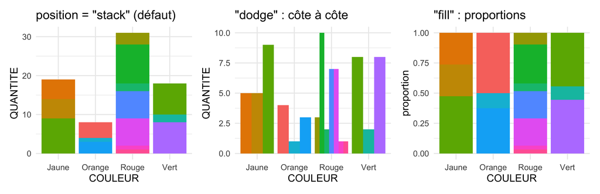

```r
ggplot(fruit, aes(COULEUR, QUANTITE, fill = FRUIT)) + geom_col(position = "dodge")
```

Avec `"fill"`, l’axe y ne montre plus des quantités mais des **proportions** (chaque barre vaut 1) : renommer l’axe.

## Résumer dans le graphique : `stat_summary()`

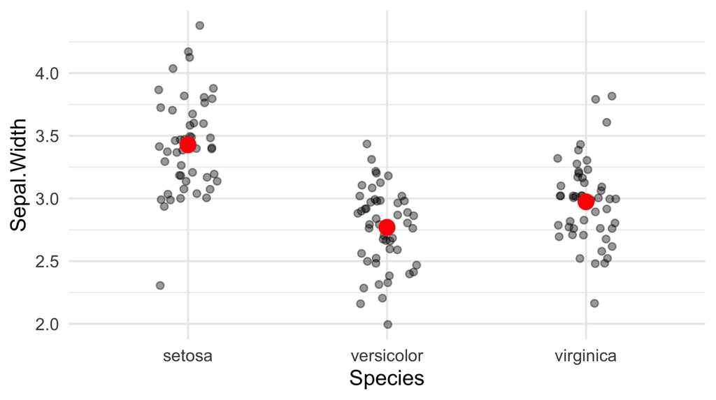

```r
ggplot(iris, aes(x = Species, y = Sepal.Width)) +
  geom_jitter(width = 0.15, alpha = 0.4) +                           # toutes les fleurs
  stat_summary(fun = mean, geom = "point", color = "red", size = 5)  # moyenne par espèce
```

Montrer **les données et leur résumé** : c’est souvent le graphique le plus honnête.

## Les échelles : `scale_*()`

Une échelle contrôle **comment une valeur devient une propriété visuelle**, et l’axe ou la légende qui va avec.

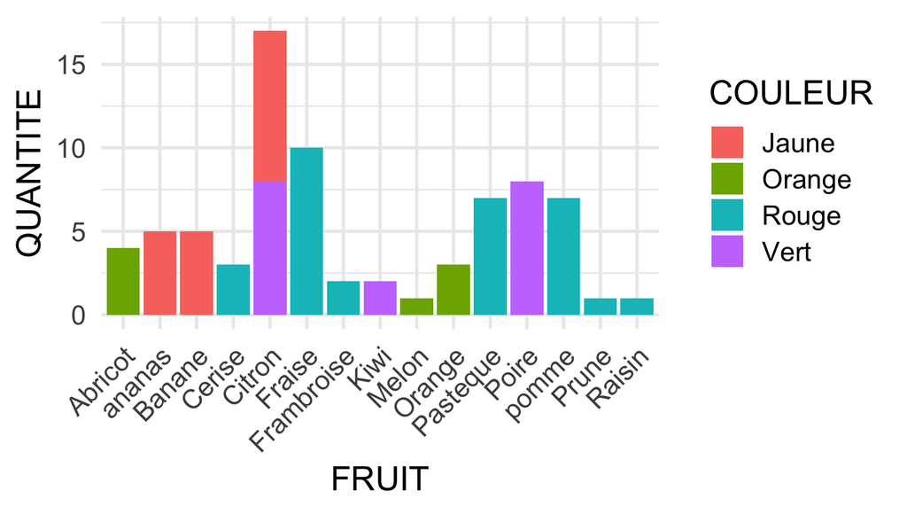

```r
ggplot(fruit, aes(FRUIT, QUANTITE,
                  fill = COULEUR)) +
  geom_col()
```

`ggplot2` ne lit pas le **contenu** : « Jaune » reçoit la première couleur de la palette (rouge saumon), « Rouge » un bleu.

```r
... + scale_fill_manual(values = c(
  Jaune = "gold", Orange = "orange",
  Rouge = "red", Vert = "green3"))
```

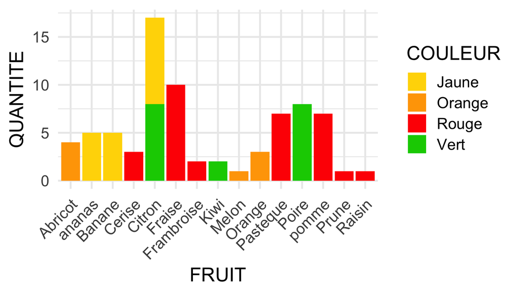

Un vecteur **nommé** : chaque catégorie reçoit sa couleur, quel que soit l’ordre.

## Les familles d’échelles

| Échelle | Usage |
| --- | --- |
| `scale_color_manual()`, `scale_fill_manual()` | couleurs choisies à la main (vecteur nommé) |
| `scale_color_viridis_d()`, `scale_fill_brewer()` | palettes prêtes à l’emploi, lisibles par les **daltoniens** |
| `scale_color_gradient(low, high)` | une variable **continue** : un dégradé |
| `scale_color_gradient2(low, mid, high, midpoint)` | dégradé **divergent** (log2 *fold change*, corrélations) |
| `scale_x_continuous(breaks = )`, `scale_y_continuous(labels = )` | graduations, étiquettes des axes |
| `scale_x_log10()`, `scale_y_log10()` | axe logarithmique |
| `scale_x_discrete(limits = )` | **ordre** et sélection des catégories |

Le nom se lit : `scale_` + *aesthetic* + `_` + type d’échelle.

## Piège : `limits` retire des données

Les notes de l’examen E2, sur 100. On veut « zoomer » sur la partie haute :

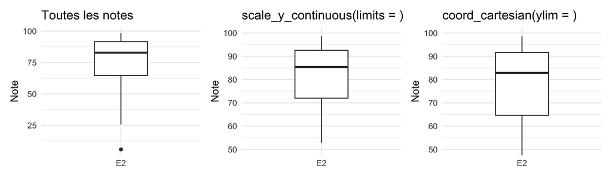

- `limits` dans une échelle **supprime** les 11 notes sous 50 **avant** de calculer le boxplot : la médiane passe de 82.86 à 85.39. Seul un *warning* le signale : « Removed 11 rows containing non-finite outside the scale range »
- `coord_cartesian()` **zoome** : toutes les données sont gardées, le boxplot est juste
- Même piège avec `xlim()`, `ylim()` : ce sont des raccourcis pour `limits`

## Les systèmes de coordonnées

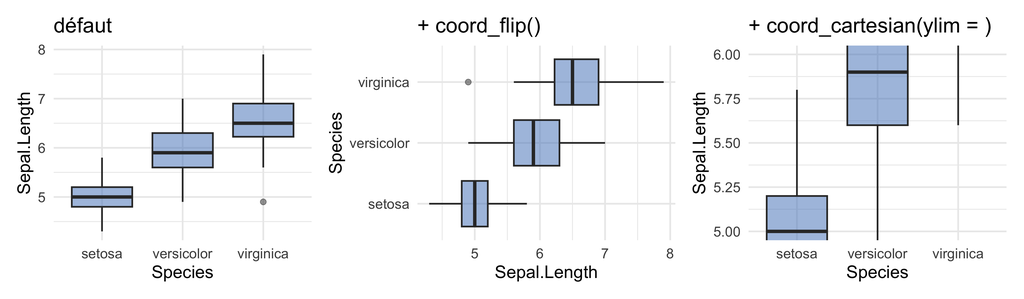

- `coord_cartesian(xlim, ylim)` : **zoomer** sans retirer de données
- `coord_flip()` : échanger x et y (étiquettes longues : on peut aussi écrire `aes(y = categorie)`)
- `coord_fixed()` : même échelle sur les deux axes (un nuage de points d’une mesure contre elle-même)

## Les facettes

Un graphique par **sous-ensemble** des données :

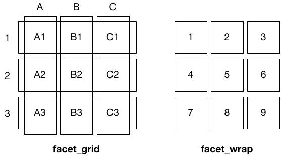

- `facet_wrap(~ var)` : un panneau par valeur, qui passe à la ligne
- `facet_grid(lignes ~ colonnes)` : une grille selon deux variables
- `scales = "free_y"` : un axe y propre à chaque panneau ; **attention** aux comparaisons entre panneaux

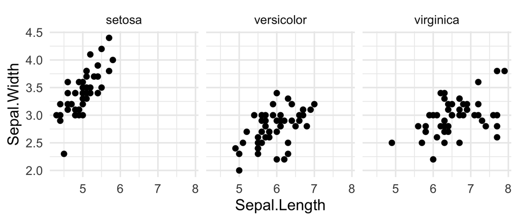

```r
ggplot(iris, aes(Sepal.Length, Sepal.Width)) +
  geom_point() +
  facet_wrap(~ Species)
```

```r
ggplot(diamonds, aes(carat, price)) +
  geom_point() + facet_grid(cut ~ color)
```